# Logistic Regression Models

Matthew Curcio

12/25/2021

## Introduction

For individuals who have studied cell biology or biochemistry, logistic regression may be familiar as dose-response curves[^1], enzyme kinetic curves[^2], median lethal dose curve (LD-50)[^3], a four parameters logistic regression, or even an exponential growth curve given limited resources[^4].

A four parameters logistic regression

$$\begin{equation}
f(x) ~=~ D + \frac{A-D}{1 + (x/C)^B}
\end{equation}$$

where:

- A = Minimum asymptote. In a bioassay, this can be thought of as the response value at 0 concentration.
- B = Hill’s slope
- C = Inflection point. The inflection point is defined as the point on the curve where the curvature changes direction or signs. C is the concentration of analyte where y=(D-A)/2.
- D = Maximum asymptote

The exponential growth curve given limited resources:

$$\begin{equation}
f(x) ~=~ \frac{M}{1 + Ae^{-r(x - x_0)}}
\end{equation}$$

where:

- $M$ is the curve’s maximum value
- $r$ is the Malthusian parameter[^5], or the log growth rate
- $x_0$ is the midpoint of the curve
- $A$ is the number of times that the initial population double to reach - $M$[^6]

Logistic regression (logit) is considered a linear regression model, as we shall see below. Understanding Logit should be studied to better understanding neural networks.

Logistic regression is useful and commonly used in predictive modeling when the output is

> finite or categorical: either A or B (binary regression) or a range of finite options A, B, C or D (multinomial regression).[^7]

The independent variables can be an array of length $N$ of real numbers, $(x \in \Re)$. While, the output is a probability between 0 and 1.

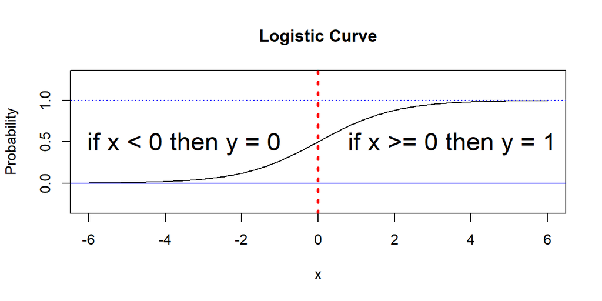

Using Logistic Regression, we may calculate the presence or absence of a product or quality that we wish to model given a difficult situation where the transition is not clear.

In the figure below, the function’s domain, $X \in \{-\infty$ to $\infty\}$, whereby its range is {0, 1}. In the figure, the *decision boundary* is $x ~=$ 0, denoted by the *red dotted line*. At the inflection point the curves range changes from *zero*, absence, to *one*, the presence of quality or item.

In the specific case of *Logistic Regression for Binary Classification* where we have a probability between 0 and 1, $M$, and $A$ take on the value one.

$$\begin{equation}
f(x) ~=~ \frac{1}{1 + e^{-(WX+b)}}
\end{equation}$$

Since the logistic equation is exponential, it is easier to work with the formula in terms of its odds or *log-odds*. Odds are the probabilities of success over failure denoted as $\Large \frac{p}{1-p}$ and more importantly, in this situation, log-odds are $ln \left (\frac{p}{1-p} \right )$.

Simply by using log-odds, logistic regression may be more easily expressed as a set of linear equations in x.[^8] Hence we can now go from linear regression to logistic regression.

Step #1:
$$\begin{equation}
ln ~ \left ( \frac{Pr(y_i ~=~ 1|x_i)}{Pr(y_i ~=~ 0|x_i)} \right ) =~ \beta_0 + \beta_1 x_1 +~ ... ~+ \beta_{n} x_{n}
\end{equation}$$

Step #2: Substitute ($p$ for $Pr(y_i ~=~ 1|x_i)$) and ($1-p$ for $Pr(y_i ~=~ 0|x_i)$) and change notation to summation on the right hand side;

$$\begin{equation}
ln \left( \frac {p}{1-p} \right) =~ \sum_i^{k} \beta_i x_i
\end{equation}$$

Step #3: Eliminate the natural log by taking the exponent on both sides;

$$\begin{equation}
\frac {p}{1-p} =~ exp \left ( \sum_i^{k} \beta_i x_i \right )
\end{equation}$$

Step #4: Substitute $u = \sum_i^{k} \beta_i x_i$;

$$\begin{equation}
\frac {p}{1-p} =~ e^u
\end{equation}$$

Step #5: Rearrange to solve for $\large p$;

$$\begin{equation}
p(u) ~=~ \frac{e^u}{1 + e^u}
\end{equation}$$

Step #6: Incidentally, to find the probabilities, take the derivative of both sides using quotient rule;

$$\begin{equation}
p'(u) ~=~ \frac {(e^u)(1 + e^u) - (e^u)(e^u)}{(1 + e^u)^2}
\end{equation}$$

Step #7: Simplify;

$$\begin{equation}
p'(u) ~=~ \frac {e^u}{(1 + e^u)^2}
\end{equation}$$

Step #8: Separate out to produce two fractions;

$$\begin{equation}
p'(u) ~=~ \left ( \frac {e^u}{1 + e^u} \right ) \cdot \left ( \frac{1}{1 + e^u} \right )
\end{equation}$$

Step #9: Substitute our previous success and failure variables back into place;

$$\begin{equation}
p'(u) ~=~ p(u) \cdot ( 1 - p(u))
\end{equation}$$

Now we can calculate the probabilities as well as the values for any given x value.

[^1]: https://en.wikipedia.org/wiki/Dose%E2%80%93response_relationship
[^2]: https://www.khanacademy.org/science/ap-biology/cellular-energetics/environmental-impacts-on-enzyme-function/a/basics-of-enzyme-kinetics-graphs
[^3]: https://en.wikipedia.org/wiki/Median_lethal_dose
[^4]: https://openoregon.pressbooks.pub/mhccmajorsbio/chapter/environmental-limits-to-population-growth/
[^5]: https://en.wikipedia.org/wiki/Malthusian_growth_model
[^6]: https://en.wikipedia.org/wiki/Logistic_function
[^7]: https://www.ibm.com/topics/logistic-regression
[^8]: http://juangabrielgomila.com/en/logistic-regression-derivation/